# LoanData by Prosper

# by Temitope Balogun

# Introduction

> Prosper is a US based lending marketplace, with over $21 billion in funded loans. Prosper generates revenue by collecting a one-time fee on funded loans from borrowers and assessing an annual loan servicing fee to investors. Borrowers can apply online which makes the process seamless. This dataset consists of 113,937 loans.

```python
# import all packages and set plots to be embedded inline
import numpy as np
import pandas as pd
import matplotlib.pyplot as plt
import seaborn as sb

%matplotlib inline
```

```python
#load the dataset into pandas
loan = pd.read_csv('prosperLoanData.csv')
```

```python
#columns in the dataset and their datatypes
print(loan.shape)
print(loan.info())
```

```
(113937, 81)
<class 'pandas.core.frame.DataFrame'>
RangeIndex: 113937 entries, 0 to 113936
Data columns (total 81 columns):
ListingKey                             113937 non-null object
ListingNumber                          113937 non-null int64
ListingCreationDate                    113937 non-null object
CreditGrade                            28953 non-null object
Term                                   113937 non-null int64
LoanStatus                             113937 non-null object
ClosedDate                             55089 non-null object
BorrowerAPR                            113912 non-null float64
BorrowerRate                           113937 non-null float64
LenderYield                            113937 non-null float64
EstimatedEffectiveYield                84853 non-null float64
EstimatedLoss                          84853 non-null float64
EstimatedReturn                        84853 non-null float64
ProsperRating (numeric)                84853 non-null float64
ProsperRating (Alpha)                  84853 non-null object
ProsperScore                           84853 non-null float64
ListingCategory (numeric)              113937 non-null int64
BorrowerState                          108422 non-null object
Occupation                             110349 non-null object
EmploymentStatus                       111682 non-null object
EmploymentStatusDuration               106312 non-null float64
IsBorrowerHomeowner                    113937 non-null bool
CurrentlyInGroup                       113937 non-null bool
GroupKey                               13341 non-null object
DateCreditPulled                       113937 non-null object
CreditScoreRangeLower                  113346 non-null float64
CreditScoreRangeUpper                  113346 non-null float64
FirstRecordedCreditLine                113240 non-null object
CurrentCreditLines                     106333 non-null float64
OpenCreditLines                        106333 non-null float64
TotalCreditLinespast7years             113240 non-null float64
OpenRevolvingAccounts                  113937 non-null int64
OpenRevolvingMonthlyPayment            113937 non-null float64
InquiriesLast6Months                   113240 non-null float64
TotalInquiries                         112778 non-null float64
CurrentDelinquencies                   113240 non-null float64
```

[output cut: 33 more lines]

```
LP_CustomerPrincipalPayments           113937 non-null float64
LP_InterestandFees                     113937 non-null float64
LP_ServiceFees                         113937 non-null float64
LP_CollectionFees                      113937 non-null float64
LP_GrossPrincipalLoss                  113937 non-null float64
LP_NetPrincipalLoss                    113937 non-null float64
LP_NonPrincipalRecoverypayments        113937 non-null float64
PercentFunded                          113937 non-null float64
Recommendations                        113937 non-null int64
InvestmentFromFriendsCount             113937 non-null int64
InvestmentFromFriendsAmount            113937 non-null float64
Investors                              113937 non-null int64
dtypes: bool(3), float64(50), int64(11), object(17)
memory usage: 68.1+ MB
None
```

### What is the structure of your dataset?

> The dataset contains 113,937 rows and 81 columns.

### What is/are the main feature(s) of interest in your dataset?

> The main feature in my dataset will be relationship between `BorrowerAPR` and `BorrowerRate`.

### What features in the dataset do you think will help support your investigation into your feature(s) of interest?

> What factors affect a loan’s outcome status?

# Wrangling

```python
#create a subset from the actual dataset
#below columns are required for my analysis
loan_new = loan[['ListingCreationDate', 'Term', 'LoanStatus','BorrowerAPR', 'BorrowerRate', 'ProsperScore', 'ListingCategory (numeric)', 'BorrowerState', 'EmploymentStatus', 'IncomeRange', 'DebtToIncomeRatio', 'StatedMonthlyIncome', 'LoanOriginalAmount']]

#check for changes
loan_new.head()
```

|  | ListingCreationDate | Term | LoanStatus | BorrowerAPR | BorrowerRate | ProsperScore | ListingCategory (numeric) | BorrowerState | EmploymentStatus | IncomeRange | DebtToIncomeRatio | StatedMonthlyIncome | LoanOriginalAmount |
| --- | --- | --- | --- | --- | --- | --- | --- | --- | --- | --- | --- | --- | --- |
| 0 | 2007-08-26 19:09:29.263000000 | 36 | Completed | 0.16516 | 0.1580 | NaN | 0 | CO | Self-employed | $25,000-49,999 | 0.17 | 3083.333333 | 9425 |
| 1 | 2014-02-27 08:28:07.900000000 | 36 | Current | 0.12016 | 0.0920 | 7.0 | 2 | CO | Employed | $50,000-74,999 | 0.18 | 6125.000000 | 10000 |
| 2 | 2007-01-05 15:00:47.090000000 | 36 | Completed | 0.28269 | 0.2750 | NaN | 0 | GA | Not available | Not displayed | 0.06 | 2083.333333 | 3001 |
| 3 | 2012-10-22 11:02:35.010000000 | 36 | Current | 0.12528 | 0.0974 | 9.0 | 16 | GA | Employed | $25,000-49,999 | 0.15 | 2875.000000 | 10000 |
| 4 | 2013-09-14 18:38:39.097000000 | 36 | Current | 0.24614 | 0.2085 | 4.0 | 2 | MN | Employed | $100,000+ | 0.26 | 9583.333333 | 15000 |

```python
loan_new.describe()
```

|  | Term | BorrowerAPR | BorrowerRate | ProsperScore | ListingCategory (numeric) | DebtToIncomeRatio | StatedMonthlyIncome | LoanOriginalAmount |
| --- | --- | --- | --- | --- | --- | --- | --- | --- |
| count | 113937.000000 | 113912.000000 | 113937.000000 | 84853.000000 | 113937.000000 | 105383.000000 | 1.139370e+05 | 113937.00000 |
| mean | 40.830248 | 0.218828 | 0.192764 | 5.950067 | 2.774209 | 0.275947 | 5.608026e+03 | 8337.01385 |
| std | 10.436212 | 0.080364 | 0.074818 | 2.376501 | 3.996797 | 0.551759 | 7.478497e+03 | 6245.80058 |
| min | 12.000000 | 0.006530 | 0.000000 | 1.000000 | 0.000000 | 0.000000 | 0.000000e+00 | 1000.00000 |
| 25% | 36.000000 | 0.156290 | 0.134000 | 4.000000 | 1.000000 | 0.140000 | 3.200333e+03 | 4000.00000 |
| 50% | 36.000000 | 0.209760 | 0.184000 | 6.000000 | 1.000000 | 0.220000 | 4.666667e+03 | 6500.00000 |
| 75% | 36.000000 | 0.283810 | 0.250000 | 8.000000 | 3.000000 | 0.320000 | 6.825000e+03 | 12000.00000 |
| max | 60.000000 | 0.512290 | 0.497500 | 11.000000 | 20.000000 | 10.010000 | 1.750003e+06 | 35000.00000 |

Based on visual and programmatic assessment, below observations were spotted

- Null values in various columns
- Incorrect naming of columns
- Wrong Data types
- Unusual Monthly income

```python
#create a new dataframe
loan_clean = loan_new.copy()

#check for duplicates
loan_clean.duplicated().sum()
```

```
0
```

```python
#check for null values in the entire dataset
loan_clean.isnull().sum()
```

```
ListingCreationDate              0
Term                             0
LoanStatus                       0
BorrowerAPR                     25
BorrowerRate                     0
ProsperScore                 29084
ListingCategory (numeric)        0
BorrowerState                 5515
EmploymentStatus              2255
IncomeRange                      0
DebtToIncomeRatio             8554
StatedMonthlyIncome              0
LoanOriginalAmount               0
dtype: int64
```

```python
#drop rows with null data
loan_clean.dropna(inplace = True)

#test code
loan_clean.isnull().sum()
```

```
ListingCreationDate          0
Term                         0
LoanStatus                   0
BorrowerAPR                  0
BorrowerRate                 0
ProsperScore                 0
ListingCategory (numeric)    0
BorrowerState                0
EmploymentStatus             0
IncomeRange                  0
DebtToIncomeRatio            0
StatedMonthlyIncome          0
LoanOriginalAmount           0
dtype: int64
```

```python
loan_clean['ListingCategory (numeric)'].value_counts()
```

```
1     49718
7      8376
2      6369
3      3650
6      2042
13     1788
15     1404
14      806
18      788
20      732
19      722
16      289
11      201
5       201
8       191
9        83
10       82
17       50
12       46
0        19
Name: ListingCategory (numeric), dtype: int64
```

```python
#descriptive statistics
loan_clean.describe()
```

|  | Term | BorrowerAPR | BorrowerRate | ProsperScore | ListingCategory (numeric) | DebtToIncomeRatio | StatedMonthlyIncome | LoanOriginalAmount |
| --- | --- | --- | --- | --- | --- | --- | --- | --- |
| count | 77557.000000 | 77557.00000 | 77557.000000 | 77557.000000 | 77557.000000 | 77557.000000 | 77557.000000 | 77557.000000 |
| mean | 42.724035 | 0.22373 | 0.193411 | 6.061967 | 3.284771 | 0.258752 | 5963.503215 | 9269.314208 |
| std | 11.711915 | 0.07916 | 0.073899 | 2.362354 | 4.385368 | 0.318326 | 5082.144391 | 6398.380615 |
| min | 12.000000 | 0.04583 | 0.040000 | 1.000000 | 0.000000 | 0.000000 | 0.250000 | 1000.000000 |
| 25% | 36.000000 | 0.16175 | 0.134900 | 4.000000 | 1.000000 | 0.150000 | 3533.333333 | 4000.000000 |
| 50% | 36.000000 | 0.21566 | 0.184500 | 6.000000 | 1.000000 | 0.220000 | 5000.000000 | 8000.000000 |
| 75% | 60.000000 | 0.28780 | 0.252400 | 8.000000 | 3.000000 | 0.320000 | 7166.666667 | 14500.000000 |
| max | 60.000000 | 0.42395 | 0.360000 | 11.000000 | 20.000000 | 10.010000 | 483333.333333 | 35000.000000 |

```python
#rename column
loan_clean = loan_clean.rename(columns = {'ListingCategory (numeric)': 'ListingCategory'})
loan_clean = loan_clean.rename(columns = {'ListingCreationDate': 'Date'})

#with reference to the information available in data dictionary, i'll rename data in ListingCategory to their appropriate data
loan_clean['ListingCategory'].replace({0 : 'Not Available', 1 : 'Debt Consolidation', 2 : 'Home Improvement', 3: 'Business', 5 : 'Student Use', 6 : 'Auto', 7 : 'Other', 8 : 'Baby & Adoption',
                   9 : 'Boat', 10 : 'Cosmetic Procedure', 11 : 'Engagement Ring', 12 : 'Green Loans',13 : 'Household Expenses', 14 : 'Large Purchases', 15 : 'Medical or Dental', 16 : 'Motorcycle',
                  17 : 'RV', 18 : 'Taxes', 19 : 'Vacation', 20 : 'Wedding Loans'}, inplace=True)

#confirm changes
loan_clean['ListingCategory'].value_counts()
```

```
Debt Consolidation    49718
Other                  8376
Home Improvement       6369
Business               3650
Auto                   2042
Household Expenses     1788
Medical or Dental      1404
Large Purchases         806
Taxes                   788
Wedding Loans           732
Vacation                722
Motorcycle              289
Engagement Ring         201
Student Use             201
Baby & Adoption         191
Boat                     83
Cosmetic Procedure       82
RV                       50
Green Loans              46
Not Available            19
Name: ListingCategory, dtype: int64
```

```python
#checking 99th quartile to ascertian my assumptions on Monthly Income
loan_clean.StatedMonthlyIncome.quantile(0.99)
```

```
20416.666666999998
```

```python
#extract actual date from date and time
loan_clean['Date'] = pd.to_datetime(loan_clean['Date']).dt.date
#change datatype of Date column to datetime
loan_clean['Date'] = pd.to_datetime(loan_clean['Date'])

#confirm changes
loan_clean['Date'].sample(2)
```

```
23121   2012-10-07
48536   2011-09-19
Name: Date, dtype: datetime64[ns]
```

```python
#converting to category datatype

change_columns = ['Term','LoanStatus','ListingCategory','BorrowerState','EmploymentStatus']
for columns in change_columns:
    loan_clean[columns] = loan_clean[columns].astype(dtype='category')


#round up Monthly income to the nearest whole number
loan_clean['StatedMonthlyIncome'] = np.round(loan_clean['StatedMonthlyIncome'], decimals=0)

#confirm changes
print(loan_clean.info())
loan_clean.head()
```

```
<class 'pandas.core.frame.DataFrame'>
Int64Index: 77557 entries, 1 to 113936
Data columns (total 13 columns):
Date                   77557 non-null datetime64[ns]
Term                   77557 non-null category
LoanStatus             77557 non-null category
BorrowerAPR            77557 non-null float64
BorrowerRate           77557 non-null float64
ProsperScore           77557 non-null float64
ListingCategory        77557 non-null category
BorrowerState          77557 non-null category
EmploymentStatus       77557 non-null category
IncomeRange            77557 non-null object
DebtToIncomeRatio      77557 non-null float64
StatedMonthlyIncome    77557 non-null float64
LoanOriginalAmount     77557 non-null int64
dtypes: category(5), datetime64[ns](1), float64(5), int64(1), object(1)
memory usage: 5.7+ MB
None
```

|  | Date | Term | LoanStatus | BorrowerAPR | BorrowerRate | ProsperScore | ListingCategory | BorrowerState | EmploymentStatus | IncomeRange | DebtToIncomeRatio | StatedMonthlyIncome | LoanOriginalAmount |
| --- | --- | --- | --- | --- | --- | --- | --- | --- | --- | --- | --- | --- | --- |
| 1 | 2014-02-27 | 36 | Current | 0.12016 | 0.0920 | 7.0 | Home Improvement | CO | Employed | $50,000-74,999 | 0.18 | 6125.0 | 10000 |
| 3 | 2012-10-22 | 36 | Current | 0.12528 | 0.0974 | 9.0 | Motorcycle | GA | Employed | $25,000-49,999 | 0.15 | 2875.0 | 10000 |
| 4 | 2013-09-14 | 36 | Current | 0.24614 | 0.2085 | 4.0 | Home Improvement | MN | Employed | $100,000+ | 0.26 | 9583.0 | 15000 |
| 5 | 2013-12-14 | 60 | Current | 0.15425 | 0.1314 | 10.0 | Debt Consolidation | NM | Employed | $100,000+ | 0.36 | 8333.0 | 15000 |
| 6 | 2013-04-12 | 36 | Current | 0.31032 | 0.2712 | 2.0 | Debt Consolidation | KS | Employed | $25,000-49,999 | 0.27 | 2083.0 | 3000 |

```python
#483,333 is unusual for monthly salary
loan_clean.loc[loan_clean['StatedMonthlyIncome'] > 300000]
```

|  | Date | Term | LoanStatus | BorrowerAPR | BorrowerRate | ProsperScore | ListingCategory | BorrowerState | EmploymentStatus | IncomeRange | DebtToIncomeRatio | StatedMonthlyIncome | LoanOriginalAmount |
| --- | --- | --- | --- | --- | --- | --- | --- | --- | --- | --- | --- | --- | --- |
| 8066 | 2011-04-02 | 36 | Completed | 0.35643 | 0.3199 | 4.0 | Debt Consolidation | IL | Employed | $100,000+ | 0.0 | 416667.0 | 2000 |
| 17411 | 2011-04-08 | 36 | Completed | 0.35643 | 0.3199 | 5.0 | Debt Consolidation | HI | Employed | $100,000+ | 0.0 | 483333.0 | 7500 |
| 57133 | 2011-03-24 | 36 | Current | 0.35643 | 0.3199 | 5.0 | Home Improvement | CT | Employed | $100,000+ | 0.0 | 466667.0 | 4000 |
| 113270 | 2013-02-20 | 36 | Current | 0.22712 | 0.1899 | 6.0 | Other | CA | Employed | $100,000+ | 0.0 | 394400.0 | 2000 |

```python
#drop rows with Monthly salary above 300,000
loan_clean.drop(labels=[8066, 57133, 113270, 17411], axis = 0, inplace = True)
```

```python
#test
loan_clean.loc[loan_clean['StatedMonthlyIncome'] > 300000]
```

|  | Date | Term | LoanStatus | BorrowerAPR | BorrowerRate | ProsperScore | ListingCategory | BorrowerState | EmploymentStatus | IncomeRange | DebtToIncomeRatio | StatedMonthlyIncome | LoanOriginalAmount |
| --- | --- | --- | --- | --- | --- | --- | --- | --- | --- | --- | --- | --- | --- |

```python
#descriptive statistics
loan_clean.describe()
```

|  | BorrowerAPR | BorrowerRate | ProsperScore | DebtToIncomeRatio | StatedMonthlyIncome | LoanOriginalAmount |
| --- | --- | --- | --- | --- | --- | --- |
| count | 77553.000000 | 77553.000000 | 77553.000000 | 77553.000000 | 77553.000000 | 77553.000000 |
| mean | 0.223725 | 0.193406 | 6.062022 | 0.258765 | 5941.104483 | 9269.592434 |
| std | 0.079158 | 0.073897 | 2.362398 | 0.318329 | 4004.140420 | 6398.407992 |
| min | 0.045830 | 0.040000 | 1.000000 | 0.000000 | 0.000000 | 1000.000000 |
| 25% | 0.161750 | 0.134900 | 4.000000 | 0.150000 | 3533.000000 | 4000.000000 |
| 50% | 0.215660 | 0.184500 | 6.000000 | 0.220000 | 5000.000000 | 8000.000000 |
| 75% | 0.287800 | 0.252400 | 8.000000 | 0.320000 | 7167.000000 | 14500.000000 |
| max | 0.423950 | 0.360000 | 11.000000 | 10.010000 | 158333.000000 | 35000.000000 |

## Univariate Exploration

## What is the distribution of BorrowerAPR and Loan Amount

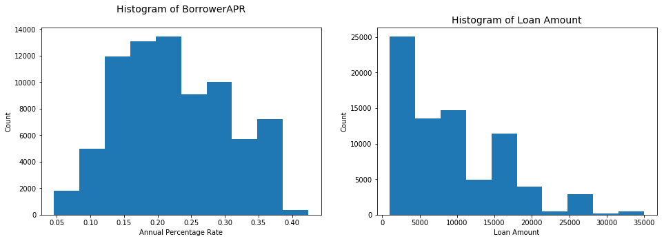

```python
plt.figure(figsize=[16, 5])

#plot histogram for BorrowerAPR
plt.subplot(1 ,2, 1)
plt.hist(data = loan_clean, x= 'BorrowerAPR')
plt.title('Histogram of BorrowerAPR\n', fontsize = 14)
plt.xlabel('Annual Percentage Rate')
plt.ylabel('Count')

#plot histogram for LoanOriginalAmount
plt.subplot(1 ,2, 2)
plt.hist(data = loan_clean, x= 'LoanOriginalAmount')
plt.title('Histogram of Loan Amount', fontsize = 14)
plt.xlabel('Loan Amount')
plt.ylabel('Count')

plt.show()
```

- Borrower's Annual percentage range shows a spike at 0.125, 0.17 and 0.2
- Loan amount appears to be right skewed.

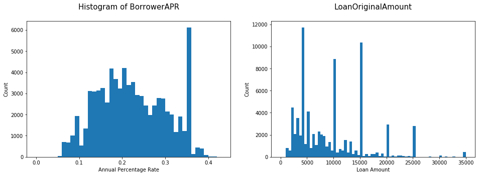

```python
plt.figure(figsize=[16, 5])

#inquire further on BorrowerAPR
plt.subplot(1 ,2, 1)
bins = np.arange(0, loan_clean['BorrowerAPR'].max()+0.01, 0.01)
plt.hist(data = loan_clean, x= 'BorrowerAPR', bins = bins)
plt.title('Histogram of BorrowerAPR\n', fontsize = 15)
plt.xlabel('Annual Percentage Rate')
plt.ylabel('Count')

#inquire further on LoanOriginalAmount
plt.subplot(1 ,2, 2)
lbins = np.arange(0, loan_clean['LoanOriginalAmount'].max()+500, 500)
plt.hist(data = loan_clean, x= 'LoanOriginalAmount', bins = lbins)
plt.title('LoanOriginalAmount\n', fontsize = 15)
plt.xlabel('Loan Amount')
plt.ylabel('Count')

plt.show()
```

#### BorrowerAPR

- Borrower's Annual Precentage Rate is multimodal
- Highest Spike for Borrower's APR is 35%

## What is the distribution of BorrowerRate and ProsperScore

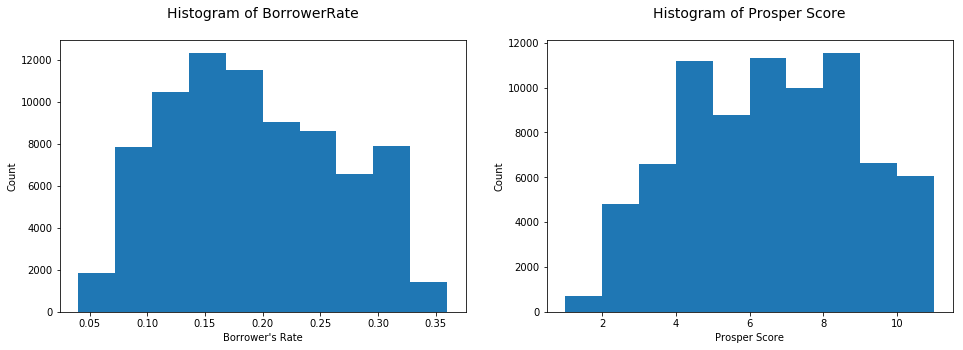

```python
plt.figure(figsize=[16, 5])

#plot histogram for BorrowerRate
plt.subplot(1 ,2, 1)
plt.hist(data = loan_clean, x= 'BorrowerRate')
plt.title('Histogram of BorrowerRate\n', fontsize = 14)
plt.xlabel("Borrower's Rate")
plt.ylabel('Count')

#plot histogram for ProsperScore
plt.subplot(1 ,2, 2)
plt.hist(data = loan_clean, x= 'ProsperScore')
plt.title('Histogram of Prosper Score\n', fontsize = 14)
plt.xlabel("Prosper Score")
plt.ylabel('Count')

plt.show();
```

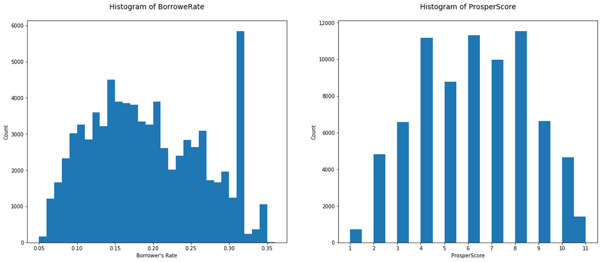

```python
plt.figure(figsize=[20, 8])

#inquire further on BorrowerRate
plt.subplot(1, 2, 1)
abins = np.arange(0.05, loan_clean['BorrowerRate'].max()+0.01, 0.01)
plt.hist(data = loan_clean, x= 'BorrowerRate', bins = abins)
plt.title('Histogram of BorroweRate\n', fontsize = 14)
plt.xlabel("Borrower's Rate")
plt.ylabel('Count')

#inquire further on ProsperScore
plt.subplot(1, 2, 2)
pbins = np.arange(1, loan_clean['ProsperScore'].max()+0.5, 0.5)
plt.hist(data = loan_clean, x= 'ProsperScore', bins = pbins)
plt.title('Histogram of ProsperScore\n', fontsize = 14)
plt.xlabel("ProsperScore")
plt.ylabel('Count')
ticks = [1,2,3,4,5,6,7,8,9,10,11]
plt.xticks(ticks)
plt.show();
```

## What is the distribution of Term?

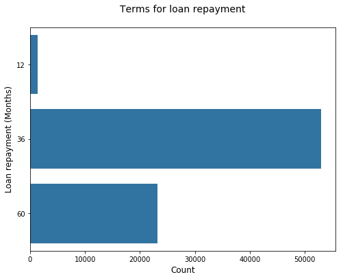

```python
#plotting  a bar chart to show the distribution of Term
plt.figure(figsize=[8,6])
base_color = sb.color_palette()[0]
sb.countplot(data= loan_clean, y = 'Term', color = base_color)
plt.title('Terms for loan repayment\n', fontsize = 14)
plt.xlabel('Count', fontsize = 12)
plt.ylabel('Loan repayment (Months)', fontsize = 12)
plt.show()
```

- Repayment period of 36 months(3 Years) is preferable for most of the Borrowers.

## What is the distribution between Loan status and Employment status?

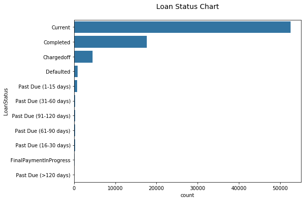

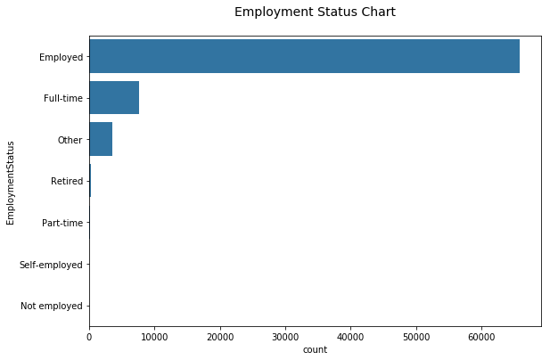

```python
plt.figure(figsize=[18,6])
#plot bar chart for Loan Status
plt.subplot(1 ,2, 1)
freq = loan_clean['LoanStatus'].value_counts()
sort_order = freq.index
base_color = sb.color_palette()[0]
sb.countplot(data= loan_clean, y = 'LoanStatus', color = base_color, order= sort_order);
plt.title('Loan Status Chart\n', fontsize = 14)
plt.show()

#plot bar chart for Employment Status
plt.figure(figsize=[20,6])
plt.subplot(1, 2, 2)
freq = loan_clean['EmploymentStatus'].value_counts()
sort_order = freq.index
base_color = sb.color_palette()[0]
sb.countplot(data= loan_clean, y = 'EmploymentStatus', color = base_color, order= sort_order);
plt.title('Employment Status Chart\n', fontsize = 14)
plt.show()
```

#### Loan Status

- Most of the loans are currently running.
- Some loans were completed.
- Some loans were charged off which means loss to the company.

#### Employment Status

- Loan Employment Status shows that Loans are granted mostly to Employed people.

## Have Sales been increasing over the years?

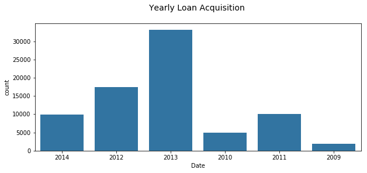

```python
#Barchart to display Years
plt.figure(figsize=[10,4])
base_color = sb.color_palette()[0]
sort_date= loan_clean['Date'].dt.to_period('Y')
plt.title('Yearly Loan Acquisition \n', fontsize = 14)
sb.countplot(data=loan_clean, x=sort_date, color = base_color);
```

- Prosper Loan had growth in their customer base from 2009 t0 2013. However, there was a drop in 2014
- High Booking of loans was recorded in 2013

## What is the distribution between Listing category and Borrower state

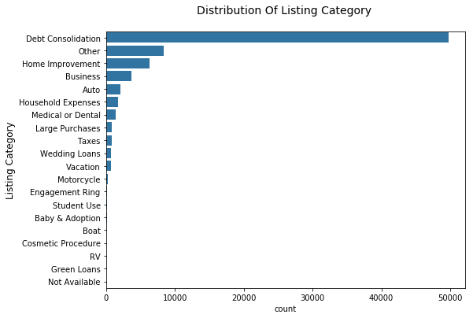

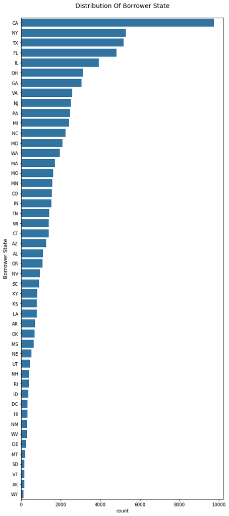

```python
plt.figure(figsize=[18,6])
#Distribution of Listing Category
plt.subplot(1 ,2, 1)
freq = loan_clean['ListingCategory'].value_counts()
sort_order = freq.index
sb.countplot(data= loan_clean, y = 'ListingCategory', color = base_color, order= sort_order)
plt.ylabel('Listing Category', fontsize = 12)
plt.title('Distribution Of Listing Category \n', fontsize = 14)
plt.show()
#Distribution of Borrower State
plt.figure(figsize=[18,20])
plt.subplot(1, 2, 2)
freq = loan_clean['BorrowerState'].value_counts()
sort_order = freq.index
sb.countplot(data= loan_clean, y = 'BorrowerState', color = base_color, order= sort_order)
plt.ylabel('Borrower State', fontsize = 12)
plt.title('Distribution Of Borrower State\n', fontsize = 14)

plt.show()
```

### Discuss the distribution(s) of your variable(s) of interest. Were there any unusual points? Did you need to perform any transformations?

> Interest rate is 32%, most loans are taken for Debt consolidation. A lot of Loans are currently running and people fron california are most popular in booking loan.

### Of the features you investigated, were there any unusual distributions? Did you perform any operations on the data to tidy, adjust, or change the form of the data? If so, why did you do this?

- In Employment status, full time and employed ought to be in same category.
- I also noticed monthly income of over 100,000 which is quite unusual.
- Prosper Score exceeds 10.

## Bivariate Exploration

### Correlation between numerical variables

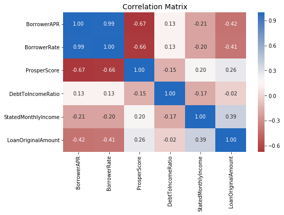

```python
#correlation plot
plt.figure(figsize = [8, 5])
sb.heatmap(loan_clean.corr(), annot = True, cmap= 'vlag_r', fmt = '.2f' )
plt.title('Correlation Matrix', fontsize = 14)
plt.show()
```

- There is negative correlation between ProsperScore and Borrower Rate
- There is negative correlation between ProsperScore and BorrowerAPR
- Positive correlation between Monthly Income and Loan Amount
- Negative correlation between Loan Amount and Borrower APR

## Relationship between Loan Amount and Borrower APR

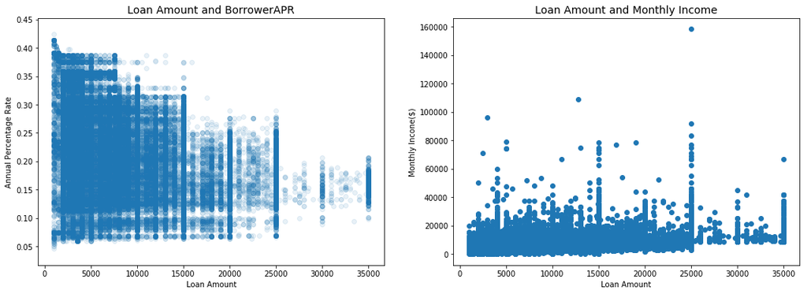

```python
plt.figure(figsize = [18, 6])
#scatter plot of Loan Amount and Borrower Rate
plt.subplot(1, 2, 1)
plt.scatter(data = loan_clean, x = 'LoanOriginalAmount', y = 'BorrowerAPR', alpha=1/10)
plt.xlabel('Loan Amount')
plt.ylabel('Annual Percentage Rate')
plt.title('Loan Amount and BorrowerAPR', fontsize = 14)

#scatter plot of Loan Amount and Monthly Income
plt.subplot(1, 2, 2)
plt.scatter(data = loan_clean, x = 'LoanOriginalAmount', y = 'StatedMonthlyIncome',)
plt.xlabel('Loan Amount')
plt.ylabel('Monthly Incone($)')
plt.title('Loan Amount and Monthly Income', fontsize = 14)
plt.show()
```

- The Relationship between Borrower APR and Loan amount is Negative.
- The Higher the loan, the lower the charges paid by the Borrower

### Relationship between Loan Amount and Employment Status

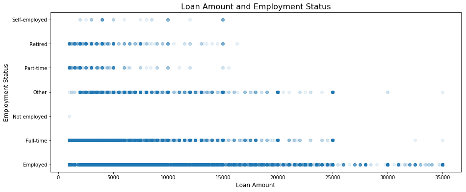

```python
#scatter plot of Loan Amount and Employment status
plt.figure(figsize = [15, 6])
plt.scatter(data = loan_clean, x = 'LoanOriginalAmount', y = 'EmploymentStatus', alpha=1/10)
plt.xlabel('Loan Amount',fontsize = 12)
plt.ylabel('Employment Status', fontsize = 12)
plt.title('Loan Amount and Employment Status', fontsize = 16)
plt.show()
```

## How do Borrowers repay their loan?

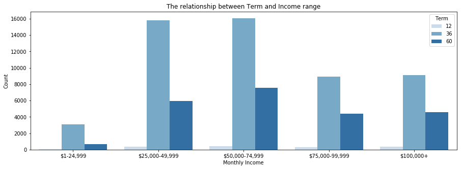

```python
#countplot between Term an Income Range
plt.figure(figsize=[15,5])
sort_income_order=['$1-24,999','$25,000-49,999','$50,000-74,999','$75,000-99,999','$100,000+']
income=pd.api.types.CategoricalDtype(ordered=True, categories=sort_income_order)
loan_clean['IncomeRange']=loan_clean['IncomeRange'].astype(income)

sb.countplot(data = loan_clean, x='IncomeRange', hue='Term', palette= 'Blues');
plt.xlabel('Monthly Income');
plt.ylabel('Count');
plt.title('The relationship between Term and Income range');
plt.show()
```

## How does Prosper Score affect lending?

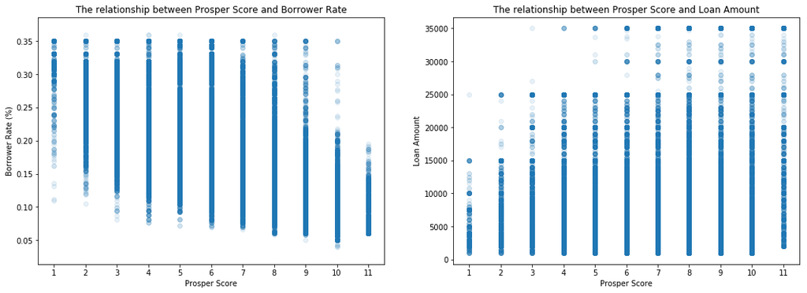

```python
plt.figure(figsize = [18, 6])
#Scatterplot of ProsperScore and Borrower Rate
plt.subplot(1, 2, 1)
plt.scatter(data = loan_clean, x = 'ProsperScore', y = 'BorrowerRate', alpha=1/10)
plt.xlabel('Prosper Score')
plt.ylabel('Borrower Rate (%)')
plt.xticks(ticks)
plt.title('The relationship between Prosper Score and Borrower Rate')

#Scatterplot of ProsperScore and Loan Amount
plt.subplot(1, 2, 2)
plt.scatter(data = loan_clean, x = 'ProsperScore', y = 'LoanOriginalAmount', alpha=1/10)
plt.xlabel('Prosper Score')
plt.ylabel('Loan Amount')
plt.xticks(ticks)
plt.title('The relationship between Prosper Score and Loan Amount')

plt.show();
```

#### Relationship between ProsperScore and Borrower Rate

- There appears to be Negative correlation between Prosper Score and Borrower rate
- High prosper score are likely to get low interest rates

#### Relationship between ProsperScore and Loan Amount

- Borrowers who have high Prosper score tend to be granted high sum of loan.
- Positive correlation between Prosper score and Loan amount

## Relationship between Loan Amount and Borrower State

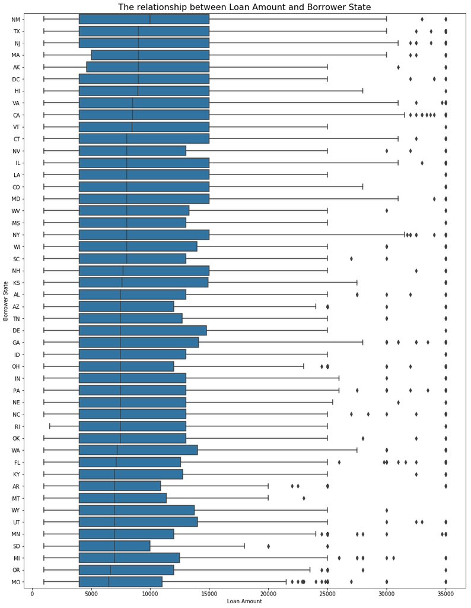

```python
#box plot to show relationship between Loan Amount and Borrower state
plt.figure(figsize=[15,20])
new_order = loan_clean.groupby(by=['BorrowerState'])['LoanOriginalAmount'].median().sort_values().iloc[::-1].index
sb.boxplot(data= loan_clean, x='LoanOriginalAmount', y='BorrowerState', color= base_color, order= new_order)
plt.xlabel('Loan Amount')
plt.ylabel('Borrower State')
plt.title('The relationship between Loan Amount and Borrower State', fontsize = 16);
```

- Top 3 median between Borrower state and Loan amount are New Mexico(NM), Texas(TX) and New Jersey(NJ)

## Relationship between Term and Loan Amount

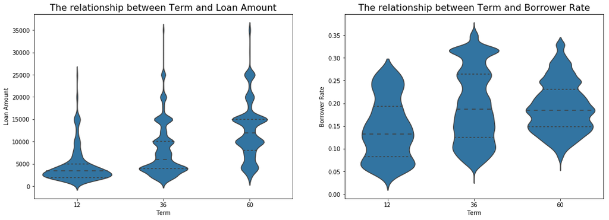

```python
plt.figure(figsize = [18, 6])
#Relationship between Term and Loan Amount
plt.subplot(1, 2, 1)
sb.violinplot(data= loan_clean, x='Term', y='LoanOriginalAmount', color=base_color, inner='quartile');
plt.xlabel('Term')
plt.ylabel('Loan Amount')
plt.title('The relationship between Term and Loan Amount', fontsize = 16);
#Relationship between Term and Borrower Rate
plt.subplot(1, 2, 2)
sb.violinplot(data= loan_clean, x='Term', y='BorrowerRate', color=base_color,inner='quartile' );
plt.xlabel('Term')
plt.ylabel('Borrower Rate')
plt.title('The relationship between Term and Borrower Rate', fontsize = 16);
```

### Did you observe any interesting relationships between the other features (not the main feature(s) of interest)?

- Borrowers who earn as high as 80,000 still take loan of 5,000.
- Borrowers take loan to repay their other debts.

## Multivariate Exploration

## Relationship between Loan Status, Borrower APR and Employment Status

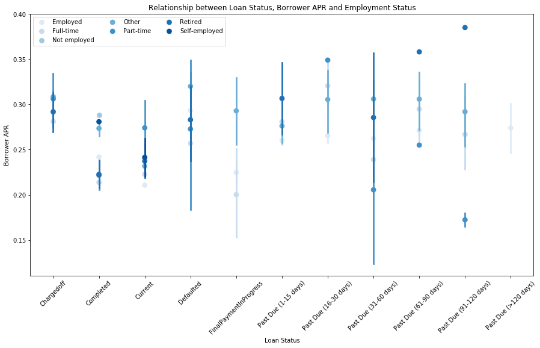

```python
#pointplot for loan status, borrower apr and employment status.
plt.figure(figsize=[15,8])
sb.pointplot(data=loan_clean,x='LoanStatus',y='BorrowerAPR', hue='EmploymentStatus',linestyles='', palette ='Blues')
plt.xticks(rotation = 45)
plt.legend(ncol=3)

plt.ylabel('Borrower APR')
plt.xlabel('Loan Status')
plt.title('Relationship between Loan Status, Borrower APR and Employment Status');
```

## Conclusions

> After investigating Proper loan, Below observations were deduced
- High prosper score Borrowers are likely to get low interest rates.
- High number of Borrowers use loan collected to service other Debts(Debt Consolidation).
- Top Borrowers are from California, New York and Texas.
- Borrowers who have high Prosper score tend to be granted high sum of loan.
- Borrowers who are employed have high chances of getting loan.

## References

- Stack Overflow website
- My classmates